# 5.2 - 8 bands kernel

```python
import sys
import os
if os.path.abspath('../sample') not in sys.path:
    sys.path.insert(0, os.path.abspath('../sample'))
if os.path.abspath('../model') not in sys.path:
    sys.path.insert(0, os.path.abspath('../model'))

from current_plot import *
import data_manipulation as dm
import autosimilarity_segmentation as as_seg
import tensor_factory as tf
import pandas as pd
import features
import numpy as np
import soundfile as sf
import NTD
import hide_code as hide
import overall_scripts as scr
```

This study is divided in 3 Notebooks, all starting with a 5.

These 3 notebooks aim at studying 3 different kernels for the convolution measure.

They should be read in their logical order.

Note, as a prerequisite, that the diagonal of all our kernels is zero. Indeed, we consider that the diagonal of autosimilarity matrices doesn't hold structural information, and that considering it is counter-productive.

More details about the design of these kernels can be found in the Notebook "Appendix - Focus on the segmentation algorithm".

# 8 bands kernel

This kernel focuses on local similarities in the 8 bars surrounding each bar of the diagonal (4 bars in the future, 4 bars in the past). Concretely, this kernel is a matrix where the only non-zero elements are the 8 closest bands parallel to the diagonal.

It looks like:

[figure not shown]

(or, in a matrix form: $\left[ \begin{matrix} 0 & 1 & 1 & 1& 1 & 0 & 0 & 0\\ 1 & 0 & 1 & 1& 1 & 1 & 0 & 0\\ 1 & 1 & 0 & 1& 1 & 1 & 1 & 0\\ 1 & 1 & 1 & 0 & 1 & 1 & 1 & 1\\ 1 & 1 & 1 & 1 & 0 & 1 & 1 & 1\\ 0 & 1 & 1 & 1 & 1 & 0 & 1 & 1\\ 0 & 0 & 1& 1 & 1 & 1 & 0 & 1\\ 0 & 0 & 0& 1 & 1 & 1 & 1 & 0\\ \end{matrix} \right]$ (of size 8 here)).

Mathematically, for a segment ($b_1, b_2$), the associated cost will be $c_{b_1,b_2} = \frac{1}{b_2 - b_1 + 1}\sum_{i,j = 0, 1 \leq |i - j| \leq 4}^{n - 1} a_{i + b_1, j + b_1}$.

## Fixed ranks

Below are segmentation results with different ranks values, but each time fixed over the entire RWC Pop dataset.

Results are computed with tolerance of respectively 0.5 seconds and 3 seconds.

```python
annotations_type = "MIREX10"
ranks_rhythm = [12,16,20,24,28,32,36,40,44,48]
ranks_pattern = [12,16,20,24,28,32,36,40,44,48]
zero_five_chr, three_chr = hide.compute_ranks_RWC(ranks_rhythm,ranks_pattern, W = "chromas", annotations_type = annotations_type,
                                                  subdivision=96, penalty_weight = 1,penalty_func = "modulo8")
```

```
C:\Users\amarmore\Desktop\Projects\PhD main projects\On Git\Code\Tensor factorization\sample\autosimilarity_segmentation.py:44: RuntimeWarning: invalid value encountered in true_divide
  this_array = np.array([list(i/np.linalg.norm(i)) for i in this_array.T]).T
```

|  | Résultats à 0.5 secondes | Vrai Positifs | Faux Positifs | Faux Négatifs | Precision | Rappel | F mesure |
| --- | --- | --- | --- | --- | --- | --- | --- |
| Rang Q:12 | Rang H:12 | 10.49 | 12.97 | 8.32 | 0.4611 | 0.5611 | 0.4997 |
|  | Rang H:16 | 10.53 | 13 | 8.28 | 0.4628 | 0.5656 | 0.5029 |
|  | Rang H:20 | 11.1 | 12.18 | 7.71 | 0.4934 | 0.593 | 0.5319 |
|  | Rang H:24 | 10.79 | 12.7 | 8.02 | 0.4741 | 0.5763 | 0.5136 |
|  | Rang H:28 | 10.85 | 12.48 | 7.96 | 0.4792 | 0.5798 | 0.5179 |
|  | Rang H:32 | 10.85 | 12.4 | 7.96 | 0.4807 | 0.5782 | 0.5187 |
|  | Rang H:36 | 10.89 | 12.51 | 7.92 | 0.4819 | 0.5816 | 0.5205 |
|  | Rang H:40 | 11.09 | 12.51 | 7.72 | 0.4877 | 0.5921 | 0.5281 |
|  | Rang H:44 | 11.03 | 12.51 | 7.78 | 0.4846 | 0.5883 | 0.5246 |
|  | Rang H:48 | 10.84 | 12.59 | 7.97 | 0.4762 | 0.5784 | 0.5158 |
| Rang Q:16 | Rang H:12 | 11.21 | 12.3 | 7.6 | 0.4983 | 0.6004 | 0.5368 |
|  | Rang H:16 | 11.29 | 12 | 7.52 | 0.5048 | 0.602 | 0.5425 |
|  | Rang H:20 | 11.51 | 12.05 | 7.3 | 0.5112 | 0.6173 | 0.5521 |
|  | Rang H:24 | 11.23 | 12.28 | 7.58 | 0.4972 | 0.6058 | 0.539 |
|  | Rang H:28 | 11.44 | 12.05 | 7.37 | 0.5065 | 0.6115 | 0.547 |
|  | Rang H:32 | 11.44 | 12.07 | 7.37 | 0.5056 | 0.6119 | 0.5464 |
|  | Rang H:36 | 11.13 | 12.33 | 7.68 | 0.4931 | 0.5938 | 0.5317 |
|  | Rang H:40 | 11.35 | 12.18 | 7.46 | 0.5009 | 0.6085 | 0.5425 |
|  | Rang H:44 | 11.44 | 12.06 | 7.37 | 0.507 | 0.6111 | 0.5474 |
|  | Rang H:48 | 11.3 | 12.02 | 7.51 | 0.5046 | 0.6037 | 0.5427 |
| Rang Q:20 | Rang H:12 | 11.58 | 11.75 | 7.23 | 0.5154 | 0.6206 | 0.5561 |
|  | Rang H:16 | 11.49 | 12 | 7.32 | 0.5069 | 0.6113 | 0.5475 |
|  | Rang H:20 | 11.72 | 11.62 | 7.09 | 0.5231 | 0.6253 | 0.5627 |
|  | Rang H:24 | 11.78 | 11.66 | 7.03 | 0.5245 | 0.6294 | 0.565 |
|  | Rang H:28 | 11.65 | 11.64 | 7.16 | 0.5216 | 0.6246 | 0.5619 |
|  | Rang H:32 | 11.74 | 11.47 | 7.07 | 0.5285 | 0.628 | 0.5672 |
|  | Rang H:36 | 11.65 | 11.64 | 7.16 | 0.5241 | 0.6255 | 0.564 |
|  | Rang H:40 | 11.84 | 11.41 | 6.97 | 0.532 | 0.6353 | 0.5722 |
|  | Rang H:44 | 11.31 | 12.13 | 7.5 | 0.507 | 0.6081 | 0.5457 |
|  | Rang H:48 | 11.56 | 11.84 | 7.25 | 0.517 | 0.618 | 0.5561 |

[output cut: 70 more lines]

|  | Résultats à 3 secondes | Vrai Positifs | Faux Positifs | Faux Négatifs | Precision | Rappel | F mesure |
| --- | --- | --- | --- | --- | --- | --- | --- |
| Rang Q:12 | Rang H:12 | 13.79 | 9.67 | 5.02 | 0.6115 | 0.7372 | 0.6602 |
|  | Rang H:16 | 14.01 | 9.52 | 4.8 | 0.6176 | 0.7478 | 0.6687 |
|  | Rang H:20 | 14.07 | 9.21 | 4.74 | 0.6281 | 0.7513 | 0.6763 |
|  | Rang H:24 | 14 | 9.49 | 4.81 | 0.6177 | 0.7475 | 0.6685 |
|  | Rang H:28 | 14.14 | 9.19 | 4.67 | 0.6299 | 0.7551 | 0.6781 |
|  | Rang H:32 | 14.21 | 9.04 | 4.6 | 0.635 | 0.7592 | 0.6832 |
|  | Rang H:36 | 14.06 | 9.34 | 4.75 | 0.6224 | 0.7513 | 0.6728 |
|  | Rang H:40 | 14.12 | 9.48 | 4.69 | 0.6222 | 0.7547 | 0.674 |
|  | Rang H:44 | 14.25 | 9.29 | 4.56 | 0.6279 | 0.7607 | 0.6799 |
|  | Rang H:48 | 14.2 | 9.23 | 4.61 | 0.6287 | 0.7595 | 0.68 |
| Rang Q:16 | Rang H:12 | 14.35 | 9.16 | 4.46 | 0.6384 | 0.7668 | 0.6877 |
|  | Rang H:16 | 14.36 | 8.93 | 4.45 | 0.6425 | 0.7671 | 0.6913 |
|  | Rang H:20 | 14.63 | 8.93 | 4.18 | 0.6485 | 0.7833 | 0.7011 |
|  | Rang H:24 | 14.46 | 9.05 | 4.35 | 0.6416 | 0.7747 | 0.6927 |
|  | Rang H:28 | 14.44 | 9.05 | 4.37 | 0.6382 | 0.7704 | 0.6898 |
|  | Rang H:32 | 14.24 | 9.27 | 4.57 | 0.6317 | 0.763 | 0.6825 |
|  | Rang H:36 | 14.17 | 9.29 | 4.64 | 0.6305 | 0.7576 | 0.6797 |
|  | Rang H:40 | 14.19 | 9.34 | 4.62 | 0.6268 | 0.7588 | 0.6784 |
|  | Rang H:44 | 14.24 | 9.26 | 4.57 | 0.6327 | 0.7614 | 0.6829 |
|  | Rang H:48 | 14.38 | 8.94 | 4.43 | 0.6434 | 0.7694 | 0.6922 |
| Rang Q:20 | Rang H:12 | 14.51 | 8.82 | 4.3 | 0.6461 | 0.7762 | 0.6967 |
|  | Rang H:16 | 14.63 | 8.86 | 4.18 | 0.6487 | 0.7817 | 0.7006 |
|  | Rang H:20 | 14.64 | 8.7 | 4.17 | 0.653 | 0.7815 | 0.7034 |
|  | Rang H:24 | 14.62 | 8.82 | 4.19 | 0.6511 | 0.7801 | 0.7013 |
|  | Rang H:28 | 14.54 | 8.75 | 4.27 | 0.6497 | 0.7789 | 0.7007 |
|  | Rang H:32 | 14.69 | 8.52 | 4.12 | 0.6598 | 0.7874 | 0.71 |
|  | Rang H:36 | 14.55 | 8.74 | 4.26 | 0.6501 | 0.7793 | 0.7012 |
|  | Rang H:40 | 14.73 | 8.52 | 4.08 | 0.6591 | 0.7897 | 0.7105 |
|  | Rang H:44 | 14.43 | 9.01 | 4.38 | 0.6424 | 0.7723 | 0.6928 |
|  | Rang H:48 | 14.66 | 8.74 | 4.15 | 0.654 | 0.784 | 0.7046 |

[output cut: 70 more lines]

## Oracle ranks

In this condition, we only keep the ranks leading to the highest F measure.

In that sense, it's an optimistic upper bound on metrics.

```python
hide.printmd("**A 0.5 secondes:**")
best_chr_zero_five = hide.best_f_one_score_rank(zero_five_chr)
hide.printmd("**A 3 secondes:**")
best_chr_three = hide.best_f_one_score_rank(three_chr)
```

**A 0.5 secondes:**

|  | Vrai Positifs | Faux Positifs | Faux Négatifs | Precision | Rappel | F mesure |
| --- | --- | --- | --- | --- | --- | --- |
| En optimisant la F mesure sur chaque chanson: | 14.6 | 7.93 | 4.21 | 0.6709 | 0.782 | 0.7146 |

**A 3 secondes:**

|  | Vrai Positifs | Faux Positifs | Faux Négatifs | Precision | Rappel | F mesure |
| --- | --- | --- | --- | --- | --- | --- |
| En optimisant la F mesure sur chaque chanson: | 16.87 | 5.29 | 1.94 | 0.7846 | 0.9022 | 0.831 |

Below is presented the distribution of the optimal ranks in the "oracle ranks" condition, *i.e.* the distribution of the ranks for $H$ and $Q$ which result in the highest F measure for the different songs.

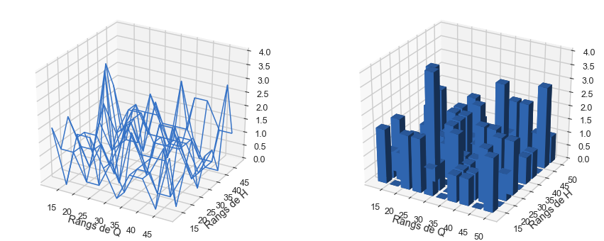

```python
hide.plot_3d_ranks_study(zero_five_chr, ranks_rhythm, ranks_pattern)
```

Below is shown the distribution histogram of the F measure obtained with the oracle ranks.

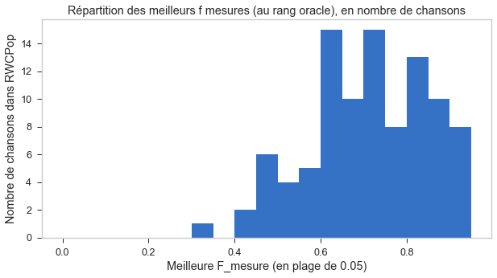

```python
hide.plot_f_mes_histogram(zero_five_chr)
```

## Results when, in addition of the ranks, we also fit the $\lambda$ parameter

In addition of the previous results, we also tried to fit the $\lambda$ parameter for each rank couple (see previous Notebook, 4th one). They are shown below.

```python
ranks_rhythm = [12,16,20,24,28,32,36,40,44,48]
ranks_pattern = [12,16,20,24,28,32,36,40,44,48]
range_param = [i/10 for i in range(0,20)]
zero_five, three = hide.compute_ranks_with_param_RWC(ranks_rhythm, ranks_pattern, range_param, annotations_type = "MIREX10", subdivision = 96, penalty_func = "modulo8")
```

|  | Résultats à 0.5 secondes | Best penalty weight | Vrai Positifs | Faux Positifs | Faux Négatifs | Precision | Rappel | F mesure |
| --- | --- | --- | --- | --- | --- | --- | --- | --- |
| Rang Q:12 | Rang H:12 | 1.1 | 10.46 | 12.56 | 8.35 | 0.468 | 0.5602 | 0.5036 |
|  | Rang H:16 | 1.2 | 10.69 | 11.86 | 8.12 | 0.4878 | 0.5734 | 0.5212 |
|  | Rang H:20 | 1.5 | 10.68 | 10.87 | 8.13 | 0.5088 | 0.5718 | 0.5325 |
|  | Rang H:24 | 1.4 | 10.61 | 11.18 | 8.2 | 0.4969 | 0.5663 | 0.5237 |
|  | Rang H:28 | 1.4 | 10.73 | 11.02 | 8.08 | 0.5051 | 0.5734 | 0.5312 |
|  | Rang H:32 | 1.1 | 10.82 | 12.04 | 7.99 | 0.486 | 0.5767 | 0.5213 |
|  | Rang H:36 | 1.4 | 10.75 | 11.14 | 8.06 | 0.5039 | 0.5742 | 0.5307 |
|  | Rang H:40 | 1 | 11.09 | 12.51 | 7.72 | 0.4877 | 0.5921 | 0.5281 |
|  | Rang H:44 | 1.8 | 10.49 | 10.49 | 8.32 | 0.5079 | 0.5604 | 0.5274 |
|  | Rang H:48 | 1.8 | 10.55 | 10.34 | 8.26 | 0.5127 | 0.563 | 0.5312 |
| Rang Q:16 | Rang H:12 | 1.4 | 11.03 | 11.06 | 7.78 | 0.5164 | 0.5897 | 0.5437 |
|  | Rang H:16 | 1.1 | 11.31 | 11.57 | 7.5 | 0.5146 | 0.6048 | 0.5496 |
|  | Rang H:20 | 0.8 | 11.81 | 12.64 | 7 | 0.5039 | 0.6305 | 0.5528 |
|  | Rang H:24 | 1.2 | 11.14 | 11.47 | 7.67 | 0.5084 | 0.5996 | 0.544 |
|  | Rang H:28 | 1.3 | 11.18 | 11.08 | 7.63 | 0.5193 | 0.5982 | 0.5495 |
|  | Rang H:32 | 1.4 | 11.12 | 10.87 | 7.69 | 0.5187 | 0.5951 | 0.5481 |
|  | Rang H:36 | 1.9 | 10.84 | 9.83 | 7.97 | 0.5338 | 0.5771 | 0.5496 |
|  | Rang H:40 | 1.4 | 11.14 | 10.88 | 7.67 | 0.5227 | 0.5972 | 0.5514 |
|  | Rang H:44 | 1.4 | 11.27 | 10.71 | 7.54 | 0.5299 | 0.6034 | 0.5584 |
|  | Rang H:48 | 1.6 | 11 | 10.35 | 7.81 | 0.5286 | 0.5884 | 0.5512 |
| Rang Q:20 | Rang H:12 | 1.1 | 11.48 | 11.44 | 7.33 | 0.5196 | 0.615 | 0.5566 |
|  | Rang H:16 | 1.1 | 11.45 | 11.64 | 7.36 | 0.5161 | 0.6105 | 0.5526 |
|  | Rang H:20 | 0.9 | 11.83 | 11.87 | 6.98 | 0.5204 | 0.6318 | 0.5636 |
|  | Rang H:24 | 1.6 | 11.33 | 10 | 7.48 | 0.5461 | 0.6037 | 0.5678 |
|  | Rang H:28 | 1.4 | 11.42 | 10.53 | 7.39 | 0.5371 | 0.6119 | 0.5659 |
|  | Rang H:32 | 1.2 | 11.77 | 10.66 | 7.04 | 0.5464 | 0.6308 | 0.5791 |
|  | Rang H:36 | 1.2 | 11.56 | 11 | 7.25 | 0.535 | 0.6204 | 0.5686 |
|  | Rang H:40 | 1.2 | 11.89 | 10.65 | 6.92 | 0.5506 | 0.6379 | 0.5841 |
|  | Rang H:44 | 1.3 | 11.16 | 11.07 | 7.65 | 0.5224 | 0.5986 | 0.5514 |
|  | Rang H:48 | 1.2 | 11.45 | 11.17 | 7.36 | 0.5259 | 0.6115 | 0.5592 |

[output cut: 70 more lines]

|  | Résultats à 3 secondes | Vrai Positifs | Faux Positifs | Faux Négatifs | Precision | Rappel | F mesure |
| --- | --- | --- | --- | --- | --- | --- | --- |
| Rang Q:12 | Rang H:12 | 13.8 | 9.22 | 5.01 | 0.6212 | 0.7376 | 0.6664 |
|  | Rang H:16 | 13.99 | 8.56 | 4.82 | 0.6393 | 0.7465 | 0.6813 |
|  | Rang H:20 | 13.74 | 7.81 | 5.07 | 0.656 | 0.7356 | 0.6866 |
|  | Rang H:24 | 13.95 | 7.84 | 4.86 | 0.66 | 0.7456 | 0.6929 |
|  | Rang H:28 | 14.2 | 7.55 | 4.61 | 0.674 | 0.759 | 0.7065 |
|  | Rang H:32 | 14.28 | 8.58 | 4.53 | 0.6461 | 0.7615 | 0.6908 |
|  | Rang H:36 | 14.05 | 7.84 | 4.76 | 0.6608 | 0.7515 | 0.6959 |
|  | Rang H:40 | 14.12 | 9.48 | 4.69 | 0.6222 | 0.7547 | 0.674 |
|  | Rang H:44 | 13.84 | 7.14 | 4.97 | 0.6738 | 0.7404 | 0.6991 |
|  | Rang H:48 | 13.89 | 7 | 4.92 | 0.6798 | 0.7436 | 0.7038 |
| Rang Q:16 | Rang H:12 | 14.23 | 7.86 | 4.58 | 0.6674 | 0.7607 | 0.7028 |
|  | Rang H:16 | 14.3 | 8.58 | 4.51 | 0.6508 | 0.7659 | 0.696 |
|  | Rang H:20 | 14.65 | 9.8 | 4.16 | 0.6262 | 0.7831 | 0.6872 |
|  | Rang H:24 | 14.32 | 8.29 | 4.49 | 0.6549 | 0.7668 | 0.6983 |
|  | Rang H:28 | 14.24 | 8.02 | 4.57 | 0.6616 | 0.761 | 0.7003 |
|  | Rang H:32 | 14.14 | 7.85 | 4.67 | 0.6615 | 0.7571 | 0.6987 |
|  | Rang H:36 | 13.96 | 6.71 | 4.85 | 0.6883 | 0.7437 | 0.7088 |
|  | Rang H:40 | 13.98 | 8.04 | 4.83 | 0.6565 | 0.7465 | 0.6913 |
|  | Rang H:44 | 14.24 | 7.74 | 4.57 | 0.6694 | 0.762 | 0.7056 |
|  | Rang H:48 | 14.19 | 7.16 | 4.62 | 0.6835 | 0.7589 | 0.7122 |
| Rang Q:20 | Rang H:12 | 14.53 | 8.39 | 4.28 | 0.6579 | 0.7777 | 0.7047 |
|  | Rang H:16 | 14.5 | 8.59 | 4.31 | 0.6542 | 0.7754 | 0.7014 |
|  | Rang H:20 | 14.67 | 9.03 | 4.14 | 0.6453 | 0.7835 | 0.6993 |
|  | Rang H:24 | 14.22 | 7.11 | 4.59 | 0.6871 | 0.7593 | 0.7146 |
|  | Rang H:28 | 14.38 | 7.57 | 4.43 | 0.6775 | 0.7707 | 0.7139 |
|  | Rang H:32 | 14.65 | 7.78 | 4.16 | 0.6781 | 0.7854 | 0.7202 |
|  | Rang H:36 | 14.54 | 8.02 | 4.27 | 0.6693 | 0.7796 | 0.713 |
|  | Rang H:40 | 14.66 | 7.88 | 4.15 | 0.6757 | 0.7851 | 0.7182 |
|  | Rang H:44 | 14.23 | 8 | 4.58 | 0.6635 | 0.761 | 0.7011 |
|  | Rang H:48 | 14.47 | 8.15 | 4.34 | 0.6637 | 0.7738 | 0.7069 |

[output cut: 70 more lines]